# functionalizing_rasters_NEON

Allie Weill

June 21, 2016

## Objectives

1. Start by putting up objectives/tasks that students will be working though:
2. Import a raster — A lidar canopy height model (lidar/Teak_lidarCHM.tif)
3. For the CHM, set values == 0 to NA (not trees)
4. Classify the raster according to some distribution – low medium and tall trees. This could be done using a histogram potentially or we could just decide that <2m is generally grasses / understory, <6m small trees,and the rest are tall trees. A function could import the desired thresholds. Visualize histogram/density and plot vertical cutoff lines.
5. Take the chm and create a hillshade (http://neon-workwithdata.github.io/neon-data-institute-2016/R/create-hillshade-R/)
6. PLOT - layer the classified raster on top of the hillshade, add a legend for each “class” - legends are super tricky to simplifying this process with a function would be good. see: http://neon-workwithdata.github.io/neon-data-institute-2016/R/classify-by-threshold-R/ for my take on forcing a legend outside of the plot area using par settings. You may have other better forms of magic to make this work well. :)
7. Export the plot figure to a pdf – publishable
8. Export the classified raster as a geotiff with NaFlagg = -9999 to an outputs folder.

## Libraries

```r
library(raster)
library(rhdf5)
library(rgdal)
library(neonAOP)
```

## Import raster

```r
chm <- raster("../NEONdata/D17-California/TEAK/2013/lidar/TEAK_lidarCHM.tif")
#assign chm values of 0 to NA
chm[chm==0] <- NA
chm
```

```
## class       : RasterLayer
## dimensions  : 577, 543, 313311  (nrow, ncol, ncell)
## resolution  : 1, 1  (x, y)
## extent      : 325963, 326506, 4102905, 4103482  (xmin, xmax, ymin, ymax)
## coord. ref. : +proj=utm +zone=11 +datum=WGS84 +units=m +no_defs +ellps=WGS84 +towgs84=0,0,0
## data source : in memory
## names       : TEAK_lidarCHM
## values      : 2.01, 55.68  (min, max)
```

```r
# dsm = digital surface model == top of canopy
dsm <- raster("../NEONdata/D17-California/TEAK/2013/lidar/TEAK_lidarDSM.tif")
# dtm = digital terrain model = elevation
dtm <- raster("../NEONdata/D17-California/TEAK/2013/lidar/TEAK_lidarDTM.tif")
```

## Classify Raster

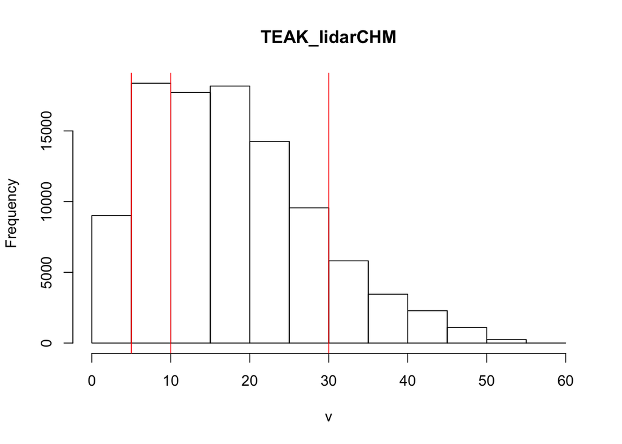

```r
hist(chm)
# first create a matrix of values that represent the classification ranges
# Not a tree (less than 1 m)=NA, 5-10 m low tree=1, 10-20 m medium tree =2, 20 m and up large tree=3
class.m <- c(0, 5, NA,
             5, 10, 1,
             10, 30, 2,
             30 ,60, 3)
abline(v=5, col="red")
abline(v=10, col="red")
abline(v=30, col="red")
```

```r
# reshape the object into a matrix with columns and rows
rcl.m <- matrix(class.m,
                ncol=3,
                byrow=TRUE)
rcl.m
```

```
##      [,1] [,2] [,3]
## [1,]    0    5   NA
## [2,]    5   10    1
## [3,]   10   30    2
## [4,]   30   60    3
```

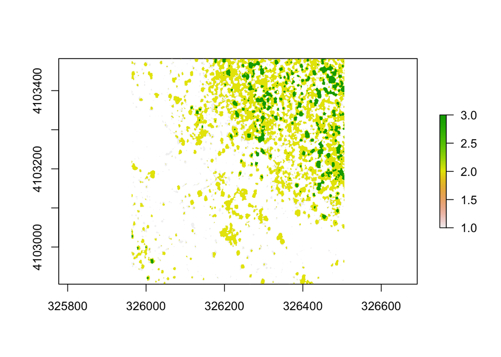

```r
chm.byHeight <- reclassify(chm,rcl.m)
plot(chm.byHeight)
```

## Save PDF

```r
pdf(file = "TEAK_CHM_density_with_breaks.pdf")
density(chm,
        xlab="Height",
        main="Canopy heights at Teakettle")
abline(v = rcl.m[,2], col="red")
dev.off()
```

## Create Hillshade

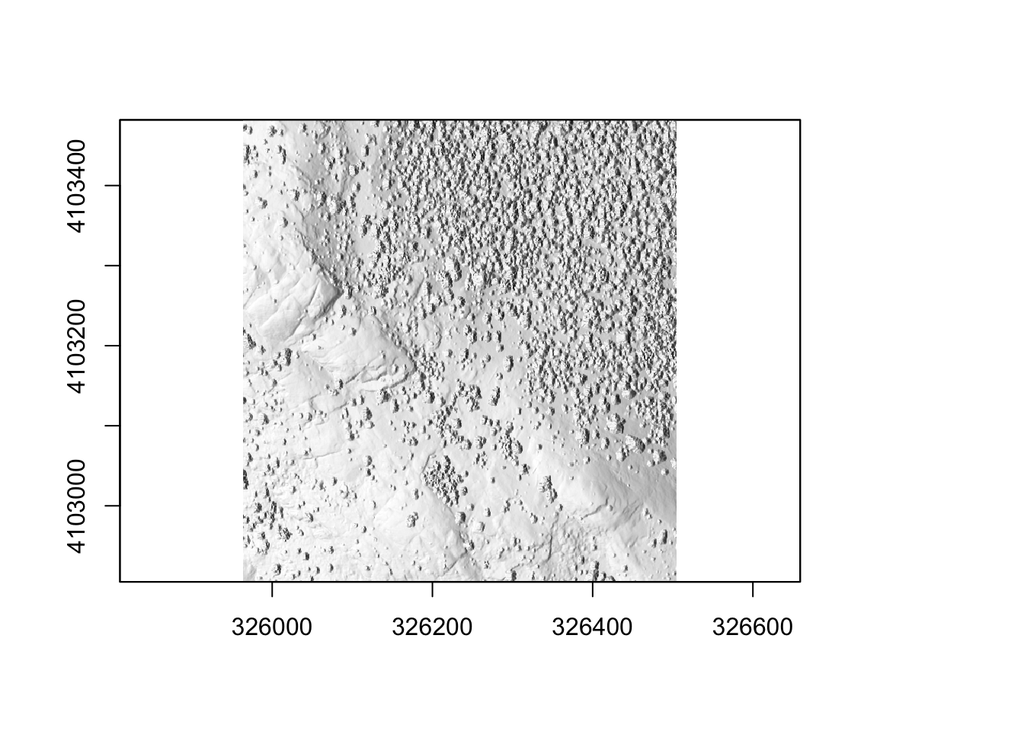

```r
slope <- terrain(dsm, opt='slope')
aspect <- terrain(dsm, opt='aspect')
# create hillshade
# numbers
dsm.hill <- hillShade(slope, aspect,
                      angle=40,
                      direction=270)
# legend outside of the plot region
# make room for a legend
par(xpd = FALSE, mar=c(5.1, 4.1, 4.1, 4.5))
plot(dsm.hill,
     col=grey.colors(100, start=0, end=1),
     legend=F)
```

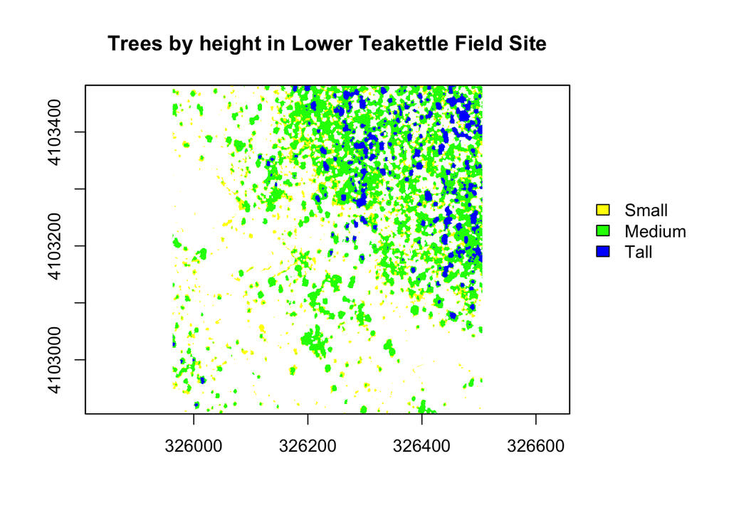

```r
# overlay CHM on top of hillshade
plot(chm.byHeight,
     add=F,
     col=c("yellow", "green","blue"),
     legend=F,
     main="Trees by height in Lower Teakettle Field Site")

# allow legend to plot outside of bounds
par(xpd=TRUE)

legend((par()$usr[2] + 20), 4103300, # set xy legend location
       legend = c("Small", "Medium", "Tall"),
       fill = c("yellow", "green","blue"),
       bty="n") # turn off border
```

## Export

```r
writeRaster(chm.byHeight,
            filename="../NEONdata/outputs/TEAK/TEAK_chm_byHeight.tif",
            format="GTiff",
            options="COMPRESS=LZW",
            overwrite = TRUE,
            NAflag = -9999)
```